# Stage 2: Exploratory Data Analysis

# Annotated Appendix

### Pitbulls

One of our research interests was to look into how different species of dogs fare in the animal shelter system. Specifically, we were interested in why pitbulls are more likely to be dead at the outcome of their time in the shelter. Does this trend continue after controlling for other variables in our dataset?

Initially we fit a model which factors in the chip status, whether or not the outcome was in the summer, and whether the dog was a pitbull or not.

```r
pitbull_binom <- adoptions %>%
  filter(!str_detect(intake_subtype, "(DEAD)|(DIED)")) %>%
  filter(dog == 1) %>%
  mutate(out_dead = outcome_type %in% c("DEAD ON ARRIVAL", "EUTHANIZED", "DIED"),
         summer = ifelse(month %in% c(5, 6, 7, 8, 9), 1, 0)) %>%
  mutate(chip_status = ifelse(chip_status=="SCAN CHIP", 1, 0)) %>%
  group_by(pitbull, chip_status, summer, month) %>%
  summarize(prop_dead = sum(out_dead)/n(), count = n())


pitbull_model1_binom <- glm(prop_dead ~ pitbull + chip_status + summer , weights = count, family = binomial, data = pitbull_binom)

pitbull_model1_quasi <- glm(prop_dead ~ pitbull + chip_status + summer , weights = count, family = quasibinomial, data = pitbull_binom)

summary(pitbull_model1_binom)
```

```
##
## Call:
## glm(formula = prop_dead ~ pitbull + chip_status + summer, family = binomial,
##     data = pitbull_binom, weights = count)
##
## Deviance Residuals:
##     Min       1Q   Median       3Q      Max
## -7.4184  -1.8174  -0.4575   1.5859   9.4807
##
## Coefficients:
##             Estimate Std. Error  z value Pr(>|z|)
## (Intercept) -2.15259    0.02131 -100.994  < 2e-16 ***
## pitbull      1.23537    0.02783   44.387  < 2e-16 ***
## chip_status -0.23649    0.03050   -7.753 8.97e-15 ***
## summer       0.37879    0.02938   12.891  < 2e-16 ***
## ---
## Signif. codes:  0 '***' 0.001 '**' 0.01 '*' 0.05 '.' 0.1 ' ' 1
##
## (Dispersion parameter for binomial family taken to be 1)
##
##     Null deviance: 2641.29  on 51  degrees of freedom
## Residual deviance:  544.19  on 48  degrees of freedom
##   (2 observations deleted due to missingness)
## AIC: 867.48
##
## Number of Fisher Scoring iterations: 4
```

```r
exp(confint(pitbull_model1_binom))
```

```
##                 2.5 %    97.5 %
## (Intercept) 0.1114096 0.1211179
## pitbull     3.2569778 3.6324244
## chip_status 0.7434426 0.8378715
## summer      1.3786281 1.5469365
```

```r
summary(pitbull_model1_quasi)
```

```
##
## Call:
## glm(formula = prop_dead ~ pitbull + chip_status + summer, family = quasibinomial,
##     data = pitbull_binom, weights = count)
##
## Deviance Residuals:
##     Min       1Q   Median       3Q      Max
## -7.4184  -1.8174  -0.4575   1.5859   9.4807
##
## Coefficients:
##             Estimate Std. Error t value Pr(>|t|)
## (Intercept) -2.15259    0.06971 -30.880  < 2e-16 ***
## pitbull      1.23537    0.09103  13.572  < 2e-16 ***
## chip_status -0.23649    0.09976  -2.371 0.021826 *
## summer       0.37879    0.09610   3.942 0.000262 ***
## ---
## Signif. codes:  0 '***' 0.001 '**' 0.01 '*' 0.05 '.' 0.1 ' ' 1
##
## (Dispersion parameter for quasibinomial family taken to be 10.69677)
##
##     Null deviance: 2641.29  on 51  degrees of freedom
## Residual deviance:  544.19  on 48  degrees of freedom
##   (2 observations deleted due to missingness)
## AIC: NA
##
## Number of Fisher Scoring iterations: 4
```

```r
exp(confint(pitbull_model1_quasi))
```

```
##                 2.5 %    97.5 %
## (Intercept) 0.1011467 0.1329404
## pitbull     2.8769183 4.1109439
## chip_status 0.6478111 0.9580232
## summer      1.2082342 1.7612914
```

Initially we see that all variables included have a significant relationship to the proportion of dogs who are dead at the end of their time in the shelter, even after inflating our standard errors to account for the variance structure of our data.

Next lets try to control for whether or not a animal was contagious when it was brought into the shelter.

```r
pitbull_binom <- adoptions %>%
  filter(!str_detect(intake_subtype, "(DEAD)|(DIED)")) %>%
  filter(dog == 1) %>%
  mutate(out_dead = outcome_type %in% c("DEAD ON ARRIVAL", "EUTHANIZED", "DIED"),
         summer = ifelse(month %in% c(5, 6, 7, 8, 9), 1, 0),
         chip_status = ifelse(chip_status=="SCAN CHIP", 1, 0),
         contagious=ifelse(grepl(".*[^NON-]CONTAGIOUS", intake_condition),1,0)) %>%
  group_by(pitbull, chip_status, summer, contagious) %>%
  summarize(prop_dead = sum(out_dead)/n(), count = n())

pitbull_model2_binom <- glm(prop_dead ~ pitbull + chip_status +
                      summer + contagious, weights = count,
                    family = binomial, data = pitbull_binom)

pitbull_model2_quasi <- glm(prop_dead ~ pitbull + chip_status +
                      summer + contagious , weights = count,
                    family = quasibinomial, data = pitbull_binom)

summary(pitbull_model2_binom)
```

```
##
## Call:
## glm(formula = prop_dead ~ pitbull + chip_status + summer + contagious,
##     family = binomial, data = pitbull_binom, weights = count)
##
## Deviance Residuals:
##      Min        1Q    Median        3Q       Max
## -2.89655  -1.32251  -0.08517   1.08867   2.12765
##
## Coefficients:
##             Estimate Std. Error  z value Pr(>|z|)
## (Intercept) -2.20165    0.02169 -101.518  < 2e-16 ***
## pitbull      1.23078    0.02814   43.742  < 2e-16 ***
## chip_status -0.22483    0.03077   -7.306 2.74e-13 ***
## summer       0.36978    0.02969   12.456  < 2e-16 ***
## contagious   1.98593    0.08113   24.477  < 2e-16 ***
## ---
## Signif. codes:  0 '***' 0.001 '**' 0.01 '*' 0.05 '.' 0.1 ' ' 1
##
## (Dispersion parameter for binomial family taken to be 1)
##
##     Null deviance: 2699.882  on 15  degrees of freedom
## Residual deviance:   32.758  on 11  degrees of freedom
##   (2 observations deleted due to missingness)
## AIC: 143.79
##
## Number of Fisher Scoring iterations: 3
```

```r
exp(confint(pitbull_model2_binom))
```

```
##                 2.5 %    97.5 %
## (Intercept) 0.1059964 0.1154017
## pitbull     3.2401347 3.6179798
## chip_status 0.7517627 0.8481433
## summer      1.3654369 1.5339545
## contagious  6.2166833 8.5454709
```

```r
summary(pitbull_model2_quasi)
```

```
##
## Call:
## glm(formula = prop_dead ~ pitbull + chip_status + summer + contagious,
##     family = quasibinomial, data = pitbull_binom, weights = count)
##
## Deviance Residuals:
##      Min        1Q    Median        3Q       Max
## -2.89655  -1.32251  -0.08517   1.08867   2.12765
##
## Coefficients:
##             Estimate Std. Error t value Pr(>|t|)
## (Intercept) -2.20165    0.03766 -58.455 4.54e-15 ***
## pitbull      1.23078    0.04887  25.187 4.45e-11 ***
## chip_status -0.22483    0.05344  -4.207  0.00147 **
## summer       0.36978    0.05156   7.172 1.82e-05 ***
## contagious   1.98593    0.14091  14.094 2.19e-08 ***
## ---
## Signif. codes:  0 '***' 0.001 '**' 0.01 '*' 0.05 '.' 0.1 ' ' 1
##
## (Dispersion parameter for quasibinomial family taken to be 3.01608)
##
##     Null deviance: 2699.882  on 15  degrees of freedom
## Residual deviance:   32.758  on 11  degrees of freedom
##   (2 observations deleted due to missingness)
## AIC: NA
##
## Number of Fisher Scoring iterations: 3
```

```r
exp(confint(pitbull_model2_quasi))
```

```
##                 2.5 %    97.5 %
## (Intercept) 0.1026891 0.1190278
## pitbull     3.1110085 3.7678996
## chip_status 0.7188083 0.8863497
## summer      1.3078316 1.6007855
## contagious  5.5323688 9.6176550
```

Next lets try to control for whether or not a animal was treatable when it was brought into the shelter.

```r
pitbull_binom <- adoptions %>%
  filter(!str_detect(intake_subtype, "(DEAD)|(DIED)")) %>%
  filter(dog == 1) %>%
  mutate(out_dead = outcome_type %in% c("DEAD ON ARRIVAL", "EUTHANIZED", "DIED"),
         summer = ifelse(month %in% c(5, 6, 7, 8, 9), 1, 0),
         chip_status = ifelse(chip_status=="SCAN CHIP", 1, 0),
         contagious=ifelse(grepl(".*[^NON-]CONTAGIOUS", intake_condition),1,0),
         treatable=ifelse(grepl("^TREATABLE.*", intake_condition),1,0)) %>%
  group_by(pitbull, chip_status, summer, month, contagious, treatable) %>%
  summarize(prop_dead = sum(out_dead)/n(), count = n())

pitbull_model3_binom <- glm(prop_dead ~ pitbull + chip_status +
                      summer + contagious + treatable, weights = count,
                    family = binomial, data = pitbull_binom)

pitbull_model3_quasi <- glm(prop_dead ~ pitbull + chip_status +
                      summer + contagious + treatable,
                      weights = count,
                      family = quasibinomial, data = pitbull_binom)

summary(pitbull_model3_binom)
```

```
##
## Call:
## glm(formula = prop_dead ~ pitbull + chip_status + summer + contagious +
##     treatable, family = binomial, data = pitbull_binom, weights = count)
##
## Deviance Residuals:
##     Min       1Q   Median       3Q      Max
## -6.0491  -1.4236  -0.1897   0.9336   9.5936
##
## Coefficients:
##             Estimate Std. Error z value Pr(>|z|)
## (Intercept) -0.59457    0.03949  -15.06  < 2e-16 ***
## pitbull      1.24955    0.02925   42.72  < 2e-16 ***
## chip_status -0.24774    0.03176   -7.80 6.21e-15 ***
## summer       0.39095    0.03070   12.73  < 2e-16 ***
## contagious   1.38010    0.08913   15.48  < 2e-16 ***
## treatable   -1.82378    0.03953  -46.14  < 2e-16 ***
## ---
## Signif. codes:  0 '***' 0.001 '**' 0.01 '*' 0.05 '.' 0.1 ' ' 1
##
## (Dispersion parameter for binomial family taken to be 1)
##
##     Null deviance: 5475.42  on 194  degrees of freedom
## Residual deviance:  842.76  on 189  degrees of freedom
##   (2 observations deleted due to missingness)
## AIC: 1514.1
##
## Number of Fisher Scoring iterations: 4
```

```r
exp(confint(pitbull_model3_binom))
```

```
##                 2.5 %    97.5 %
## (Intercept) 0.5106406 0.5961339
## pitbull     3.2943807 3.6946299
## chip_status 0.7333041 0.8305406
## summer      1.3918868 1.5699049
## contagious  3.3384762 4.7351594
## treatable   0.1493824 0.1744212
```

```r
summary(pitbull_model3_quasi)
```

```
##
## Call:
## glm(formula = prop_dead ~ pitbull + chip_status + summer + contagious +
##     treatable, family = quasibinomial, data = pitbull_binom,
##     weights = count)
##
## Deviance Residuals:
##     Min       1Q   Median       3Q      Max
## -6.0491  -1.4236  -0.1897   0.9336   9.5936
##
## Coefficients:
##             Estimate Std. Error t value Pr(>|t|)
## (Intercept) -0.59457    0.08240  -7.216 1.26e-11 ***
## pitbull      1.24955    0.06104  20.472  < 2e-16 ***
## chip_status -0.24774    0.06628  -3.738 0.000246 ***
## summer       0.39095    0.06407   6.102 5.80e-09 ***
## contagious   1.38010    0.18600   7.420 3.86e-12 ***
## treatable   -1.82378    0.08249 -22.110  < 2e-16 ***
## ---
## Signif. codes:  0 '***' 0.001 '**' 0.01 '*' 0.05 '.' 0.1 ' ' 1
##
## (Dispersion parameter for quasibinomial family taken to be 4.354402)
##
##     Null deviance: 5475.42  on 194  degrees of freedom
## Residual deviance:  842.76  on 189  degrees of freedom
##   (2 observations deleted due to missingness)
## AIC: NA
##
## Number of Fisher Scoring iterations: 4
```

```r
exp(confint(pitbull_model3_quasi))
```

```
##                 2.5 %    97.5 %
## (Intercept) 0.4692407 0.6482124
## pitbull     3.0952904 3.9321196
## chip_status 0.6848701 0.8881191
## summer      1.3032732 1.6754195
## contagious  2.7616713 5.7307395
## treatable   0.1373228 0.1897619
```

Note that these models have different confidence intervals than the ones mentioned in the main report of our paper. While each of the three models in the appendix was fit on a dataset summarised specifically for each model, the models in the main report were all fit using the same dataset. By using the same dataset we can compare models using nested F tests, but SEs may be artificially small.

### Dogs vs Cats

```r
cat_dog_binom <- adoptions %>%
  filter(!str_detect(intake_subtype, "(DEAD)|(DIED)")) %>%
  filter(dog == 1 | cat == 1) %>%
  mutate(out_dead = outcome_type %in% c("DEAD ON ARRIVAL", "EUTHANIZED", "DIED"),
         summer = ifelse(month %in% c(5, 6, 7, 8, 9), 1, 0))%>%
  mutate(chip_status = ifelse(chip_status=="SCAN CHIP", 1, 0)) %>%
  group_by(dog, chip_status, summer, stray) %>%
  summarize(prop_dead = sum(out_dead)/n(), count = n())

####### MODEL 1: dog #########

dogcat_model1_binom <- glm(prop_dead ~ dog, weights = count, family = binomial, data = cat_dog_binom)

dogcat_model1_quasi <- glm(prop_dead ~ dog, weights = count, family = quasibinomial, data = cat_dog_binom)

summary(dogcat_model1_binom)
```

```
##
## Call:
## glm(formula = prop_dead ~ dog, family = binomial, data = cat_dog_binom,
##     weights = count)
##
## Deviance Residuals:
##     Min       1Q   Median       3Q      Max
## -19.837   -7.385   -2.250    4.985   15.639
##
## Coefficients:
##             Estimate Std. Error z value Pr(>|z|)
## (Intercept) -1.43741    0.02199  -65.38   <2e-16 ***
## dog         -0.30509    0.02563  -11.90   <2e-16 ***
## ---
## Signif. codes:  0 '***' 0.001 '**' 0.01 '*' 0.05 '.' 0.1 ' ' 1
##
## (Dispersion parameter for binomial family taken to be 1)
##
##     Null deviance: 1883.0  on 17  degrees of freedom
## Residual deviance: 1745.6  on 16  degrees of freedom
## AIC: 1866
##
## Number of Fisher Scoring iterations: 4
```

```r
exp(confint(dogcat_model1_binom))
```

```
##                 2.5 %    97.5 %
## (Intercept) 0.2274800 0.2479563
## dog         0.7010303 0.7751213
```

```r
summary(dogcat_model1_quasi)
```

```
##
## Call:
## glm(formula = prop_dead ~ dog, family = quasibinomial, data = cat_dog_binom,
##     weights = count)
##
## Deviance Residuals:
##     Min       1Q   Median       3Q      Max
## -19.837   -7.385   -2.250    4.985   15.639
##
## Coefficients:
##             Estimate Std. Error t value Pr(>|t|)
## (Intercept)  -1.4374     0.2249  -6.393 8.91e-06 ***
## dog          -0.3051     0.2621  -1.164    0.261
## ---
## Signif. codes:  0 '***' 0.001 '**' 0.01 '*' 0.05 '.' 0.1 ' ' 1
##
## (Dispersion parameter for quasibinomial family taken to be 104.5899)
##
##     Null deviance: 1883.0  on 17  degrees of freedom
## Residual deviance: 1745.6  on 16  degrees of freedom
## AIC: NA
##
## Number of Fisher Scoring iterations: 4
```

```r
exp(confint(dogcat_model1_quasi))
```

```
##                 2.5 %    97.5 %
## (Intercept) 0.1495373 0.3624932
## dog         0.4457027 1.2501118
```

```r
####### MODEL 2: summer #########

dogcat_model2_binom <- glm(prop_dead ~ summer, weights = count, family = binomial, data = cat_dog_binom)

dogcat_model2_quasi <- glm(prop_dead ~ summer, weights = count, family = quasibinomial, data = cat_dog_binom)

summary(dogcat_model2_binom)
```

```
##
## Call:
## glm(formula = prop_dead ~ summer, family = binomial, data = cat_dog_binom,
##     weights = count)
##
## Deviance Residuals:
##     Min       1Q   Median       3Q      Max
## -18.202   -7.386   -4.440    5.671   17.663
##
## Coefficients:
##             Estimate Std. Error z value Pr(>|z|)
## (Intercept) -1.81259    0.01405  -129.0   <2e-16 ***
## summer       0.45539    0.02372    19.2   <2e-16 ***
## ---
## Signif. codes:  0 '***' 0.001 '**' 0.01 '*' 0.05 '.' 0.1 ' ' 1
##
## (Dispersion parameter for binomial family taken to be 1)
##
##     Null deviance: 1883.0  on 17  degrees of freedom
## Residual deviance: 1524.9  on 16  degrees of freedom
## AIC: 1645.3
##
## Number of Fisher Scoring iterations: 4
```

```r
exp(confint(dogcat_model2_binom))
```

```
##                 2.5 %    97.5 %
## (Intercept) 0.1587829 0.1677739
## summer      1.5050770 1.6517349
```

```r
summary(dogcat_model2_quasi)
```

```
##
## Call:
## glm(formula = prop_dead ~ summer, family = quasibinomial, data = cat_dog_binom,
##     weights = count)
##
## Deviance Residuals:
##     Min       1Q   Median       3Q      Max
## -18.202   -7.386   -4.440    5.671   17.663
##
## Coefficients:
##             Estimate Std. Error t value Pr(>|t|)
## (Intercept)  -1.8126     0.1344 -13.490 3.71e-10 ***
## summer        0.4554     0.2268   2.008   0.0619 .
## ---
## Signif. codes:  0 '***' 0.001 '**' 0.01 '*' 0.05 '.' 0.1 ' ' 1
##
## (Dispersion parameter for quasibinomial family taken to be 91.44736)
##
##     Null deviance: 1883.0  on 17  degrees of freedom
## Residual deviance: 1524.9  on 16  degrees of freedom
## AIC: NA
##
## Number of Fisher Scoring iterations: 4
```

```r
exp(confint(dogcat_model2_quasi))
```

```
##                 2.5 %    97.5 %
## (Intercept) 0.1243408 0.2107409
## summer      1.0043970 2.4491693
```

```r
####### MODEL 3: chip ######

dogcat_model3_binom <- glm(prop_dead ~ dog + chip_status, weights = count, family = binomial, data = cat_dog_binom)

dogcat_model3_quasi <- glm(prop_dead ~ dog + chip_status, weights = count, family = quasibinomial, data = cat_dog_binom)

summary(dogcat_model3_binom)
```

```
##
## Call:
## glm(formula = prop_dead ~ dog + chip_status, family = binomial,
##     data = cat_dog_binom, weights = count)
##
## Deviance Residuals:
##      Min        1Q    Median        3Q       Max
## -15.6677   -4.1391    0.1846   10.8318   14.4792
##
## Coefficients:
##             Estimate Std. Error z value Pr(>|z|)
## (Intercept) -1.40636    0.02211 -63.599   <2e-16 ***
## dog         -0.24565    0.02620  -9.377   <2e-16 ***
## chip_status -0.29305    0.02828 -10.363   <2e-16 ***
## ---
## Signif. codes:  0 '***' 0.001 '**' 0.01 '*' 0.05 '.' 0.1 ' ' 1
##
## (Dispersion parameter for binomial family taken to be 1)
##
##     Null deviance: 1750.8  on 15  degrees of freedom
## Residual deviance: 1503.0  on 13  degrees of freedom
##   (2 observations deleted due to missingness)
## AIC: 1625.4
##
## Number of Fisher Scoring iterations: 4
```

```r
exp(confint(dogcat_model3_binom))
```

```
##                 2.5 %    97.5 %
## (Intercept) 0.2345951 0.2558385
## dog         0.7431337 0.8235017
## chip_status 0.7056151 0.7883420
```

```r
summary(dogcat_model3_quasi)
```

```
##
## Call:
## glm(formula = prop_dead ~ dog + chip_status, family = quasibinomial,
##     data = cat_dog_binom, weights = count)
##
## Deviance Residuals:
##      Min        1Q    Median        3Q       Max
## -15.6677   -4.1391    0.1846   10.8318   14.4792
##
## Coefficients:
##             Estimate Std. Error t value Pr(>|t|)
## (Intercept)  -1.4064     0.2391  -5.883 5.38e-05 ***
## dog          -0.2456     0.2832  -0.867    0.401
## chip_status  -0.2931     0.3057  -0.959    0.355
## ---
## Signif. codes:  0 '***' 0.001 '**' 0.01 '*' 0.05 '.' 0.1 ' ' 1
##
## (Dispersion parameter for quasibinomial family taken to be 116.867)
##
##     Null deviance: 1750.8  on 15  degrees of freedom
## Residual deviance: 1503.0  on 13  degrees of freedom
##   (2 observations deleted due to missingness)
## AIC: NA
##
## Number of Fisher Scoring iterations: 4
```

```r
exp(confint(dogcat_model3_quasi))
```

```
##                 2.5 %    97.5 %
## (Intercept) 0.1496550 0.3838132
## dog         0.4540004 1.3839138
## chip_status 0.3987708 1.3312323
```

```r
####### MODEL 4: summer + dog + summer:dog ######

dogcat_model4_binom <- glm(prop_dead ~ summer+dog+ summer:dog, weights = count, family = binomial, data = cat_dog_binom)

dogcat_model4_quasi <- glm(prop_dead ~ summer+dog+ summer:dog, weights = count, family = quasibinomial, data = cat_dog_binom)

summary(dogcat_model4_binom)
```

```
##
## Call:
## glm(formula = prop_dead ~ summer + dog + summer:dog, family = binomial,
##     data = cat_dog_binom, weights = count)
##
## Deviance Residuals:
##     Min       1Q   Median       3Q      Max
## -17.392   -7.749   -4.789    6.527   18.670
##
## Coefficients:
##             Estimate Std. Error z value Pr(>|z|)
## (Intercept) -1.67600    0.03030 -55.313  < 2e-16 ***
## summer       0.56018    0.04434  12.634  < 2e-16 ***
## dog         -0.17185    0.03420  -5.024 5.05e-07 ***
## summer:dog  -0.18718    0.05275  -3.549 0.000387 ***
## ---
## Signif. codes:  0 '***' 0.001 '**' 0.01 '*' 0.05 '.' 0.1 ' ' 1
##
## (Dispersion parameter for binomial family taken to be 1)
##
##     Null deviance: 1883.0  on 17  degrees of freedom
## Residual deviance: 1421.8  on 14  degrees of freedom
## AIC: 1546.2
##
## Number of Fisher Scoring iterations: 4
```

```r
exp(confint(dogcat_model4_binom))
```

```
##                 2.5 %    97.5 %
## (Intercept) 0.1762591 0.1984903
## summer      1.6052408 1.9099840
## dog         0.7877336 0.9007624
## summer:dog  0.7478053 0.9195843
```

```r
summary(dogcat_model4_quasi)
```

```
##
## Call:
## glm(formula = prop_dead ~ summer + dog + summer:dog, family = quasibinomial,
##     data = cat_dog_binom, weights = count)
##
## Deviance Residuals:
##     Min       1Q   Median       3Q      Max
## -17.392   -7.749   -4.789    6.527   18.670
##
## Coefficients:
##             Estimate Std. Error t value Pr(>|t|)
## (Intercept)  -1.6760     0.2978  -5.628 6.23e-05 ***
## summer        0.5602     0.4358   1.285    0.220
## dog          -0.1718     0.3362  -0.511    0.617
## summer:dog   -0.1872     0.5185  -0.361    0.723
## ---
## Signif. codes:  0 '***' 0.001 '**' 0.01 '*' 0.05 '.' 0.1 ' ' 1
##
## (Dispersion parameter for quasibinomial family taken to be 96.60753)
##
##     Null deviance: 1883.0  on 17  degrees of freedom
## Residual deviance: 1421.8  on 14  degrees of freedom
## AIC: NA
##
## Number of Fisher Scoring iterations: 4
```

```r
exp(confint(dogcat_model4_quasi))
```

```
##                  2.5 %   97.5 %
## (Intercept) 0.09987833 0.324086
## summer      0.74071253 4.144038
## dog         0.44621757 1.682512
## summer:dog  0.29772816 2.292399
```

```r
####### MODEL 5: stray ######

dogcat_model5_binom <- glm(prop_dead ~ stray, weights = count, family = binomial, data = cat_dog_binom)

dogcat_model5_quasi <- glm(prop_dead ~ stray, weights = count, family = quasibinomial, data = cat_dog_binom)

summary(dogcat_model5_binom)
```

```
##
## Call:
## glm(formula = prop_dead ~ stray, family = binomial, data = cat_dog_binom,
##     weights = count)
##
## Deviance Residuals:
##     Min       1Q   Median       3Q      Max
## -18.398   -7.178   -2.626    4.353   23.455
##
## Coefficients:
##             Estimate Std. Error z value Pr(>|z|)
## (Intercept) -1.44258    0.01775  -81.28   <2e-16 ***
## stray       -0.36155    0.02303  -15.70   <2e-16 ***
## ---
## Signif. codes:  0 '***' 0.001 '**' 0.01 '*' 0.05 '.' 0.1 ' ' 1
##
## (Dispersion parameter for binomial family taken to be 1)
##
##     Null deviance: 1883.0  on 17  degrees of freedom
## Residual deviance: 1640.2  on 16  degrees of freedom
## AIC: 1760.6
##
## Number of Fisher Scoring iterations: 4
```

```r
exp(confint(dogcat_model5_binom))
```

```
##                2.5 %    97.5 %
## (Intercept) 0.228210 0.2446524
## stray       0.665877 0.7287805
```

```r
summary(dogcat_model5_quasi)
```

```
##
## Call:
## glm(formula = prop_dead ~ stray, family = quasibinomial, data = cat_dog_binom,
##     weights = count)
##
## Deviance Residuals:
##     Min       1Q   Median       3Q      Max
## -18.398   -7.178   -2.626    4.353   23.455
##
## Coefficients:
##             Estimate Std. Error t value Pr(>|t|)
## (Intercept)  -1.4426     0.1803  -8.002 5.53e-07 ***
## stray        -0.3616     0.2339  -1.546    0.142
## ---
## Signif. codes:  0 '***' 0.001 '**' 0.01 '*' 0.05 '.' 0.1 ' ' 1
##
## (Dispersion parameter for quasibinomial family taken to be 103.1719)
##
##     Null deviance: 1883.0  on 17  degrees of freedom
## Residual deviance: 1640.2  on 16  degrees of freedom
## AIC: NA
##
## Number of Fisher Scoring iterations: 4
```

```r
exp(confint(dogcat_model5_quasi))
```

```
##                 2.5 %    97.5 %
## (Intercept) 0.1636774 0.3324977
## stray       0.4414678 1.1069417
```

```r
just_dog_adoptions=adoptions%>%
  filter(animal_type=="DOG")%>%
  mutate(animal_breed=as.factor(animal_breed))%>%
  mutate(healthy_intake=ifelse(grepl("^HEALTHY.*",intake_condition),1,0),
         contagious_intake=ifelse(grepl(".*[^NON-]CONTAGIOUS", intake_condition),1,0),
         untreatable_intake=ifelse(grepl(".*(UNTREATABLE).*", intake_condition),1,0),
         treatable_intake=ifelse(grepl("^TREATABLE.*", intake_condition),1,0),
         manageable_intake=ifelse(grepl(".*MANAGEABLE.*", intake_condition),1,0),
         rehabitable_intake=ifelse(grepl(".*REHABILITABLE.*", intake_condition),1,0),
         normal_intake=ifelse(grepl(".*NORMAL.*", intake_condition),1,0),
         chip_status = ifelse(chip_status=="SCAN CHIP", 1, 0))%>% #Isaac added this just to see how models change
         mutate(out_dead = outcome_type %in% c("DEAD ON ARRIVAL", "EUTHANIZED", "DIED"),
         summer = ifelse(month %in% c(5, 6, 7, 8, 9), 1, 0))
```

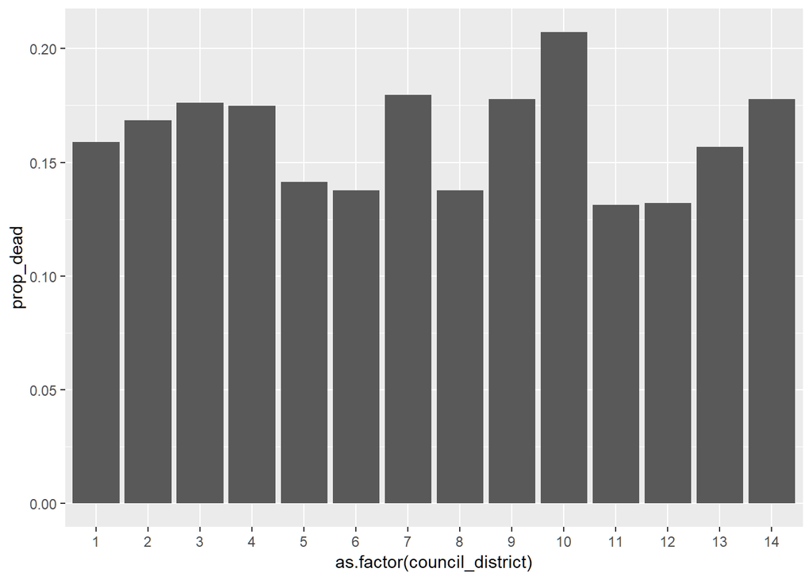

```r
just_dog_adoptions %>%
  group_by(council_district)%>%
  summarise(prop_dead = sum(out_dead)/n())%>%
  filter(!is.na(council_district))%>%
  ggplot(aes(x=as.factor(council_district), y = prop_dead)) +
  geom_bar(stat = "identity")
```

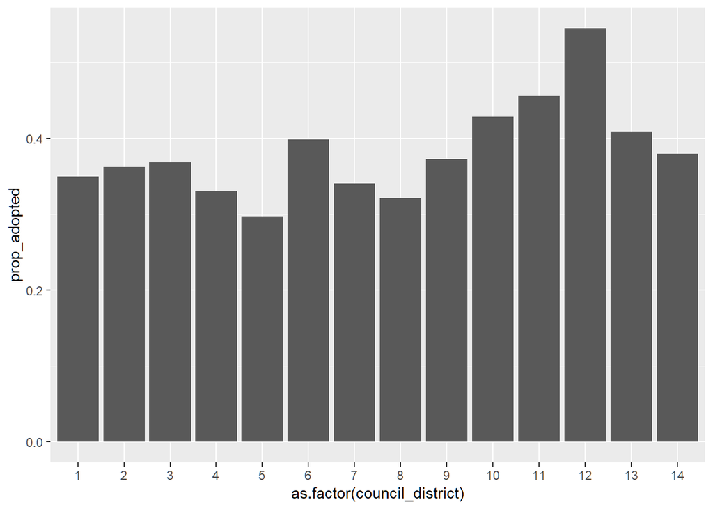

```r
just_dog_adoptions %>%
  group_by(council_district)%>%
  summarise(prop_adopted = sum(adopted)/n())%>%
  filter(!is.na(council_district)) %>%
  ggplot(aes(x=as.factor(council_district), y = prop_adopted)) +
  geom_bar(stat = "identity")
```

For proportion adopted we see a range of values. City council district 12 has 54.5% of the dogs adopted, while city council district 5 has the lowest proportion adopted at only 0.297.

### Random Intercepts:

```r
mod.1=glmer(adopted~1+(1|council_district), data=just_dog_adoptions, family = "binomial")
summary(mod.1)
```

```
## Generalized linear mixed model fit by maximum likelihood (Laplace
##   Approximation) [glmerMod]
##  Family: binomial  ( logit )
## Formula: adopted ~ 1 + (1 | council_district)
##    Data: just_dog_adoptions
##
##      AIC      BIC   logLik deviance df.resid
##  58685.9  58703.3 -29340.9  58681.9    45485
##
## Scaled residuals:
##     Min      1Q  Median      3Q     Max
## -1.0569 -0.7335 -0.6885  1.2963  1.5351
##
## Random effects:
##  Groups           Name        Variance Std.Dev.
##  council_district (Intercept) 0.05945  0.2438
## Number of obs: 45487, groups:  council_district, 14
##
## Fixed effects:
##             Estimate Std. Error z value Pr(>|z|)
## (Intercept) -0.49300    0.06663  -7.399 1.37e-13 ***
## ---
## Signif. codes:  0 '***' 0.001 '**' 0.01 '*' 0.05 '.' 0.1 ' ' 1
```

```r
exp(fixef(mod.1))/(1+exp(fixef(mod.1)))
```

```
## (Intercept)
##   0.3791861
```

```r
mod.1_dead=glmer(out_dead~1+(1|council_district), data=just_dog_adoptions, family = "binomial")
summary(mod.1_dead)
```

```
## Generalized linear mixed model fit by maximum likelihood (Laplace
##   Approximation) [glmerMod]
##  Family: binomial  ( logit )
## Formula: out_dead ~ 1 + (1 | council_district)
##    Data: just_dog_adoptions
##
##      AIC      BIC   logLik deviance df.resid
##  39522.0  39539.5 -19759.0  39518.0    45485
##
## Scaled residuals:
##     Min      1Q  Median      3Q     Max
## -0.4909 -0.4592 -0.4080 -0.4014  2.4913
##
## Random effects:
##  Groups           Name        Variance Std.Dev.
##  council_district (Intercept) 0.01946  0.1395
## Number of obs: 45487, groups:  council_district, 14
##
## Fixed effects:
##             Estimate Std. Error z value Pr(>|z|)
## (Intercept) -1.65465    0.04143  -39.94   <2e-16 ***
## ---
## Signif. codes:  0 '***' 0.001 '**' 0.01 '*' 0.05 '.' 0.1 ' ' 1
```

```r
exp(fixef(mod.1_dead))/(1+exp(fixef(mod.1_dead)))
```

```
## (Intercept)
##   0.1604818
```

### Multi-Level:

```r
mod.2.adopted=glmer(adopted~summer+chip_status+treatable_intake+(1|council_district), data=just_dog_adoptions, family = "binomial")
summary(mod.2.adopted)
```

```
## Generalized linear mixed model fit by maximum likelihood (Laplace
##   Approximation) [glmerMod]
##  Family: binomial  ( logit )
## Formula:
## adopted ~ summer + chip_status + treatable_intake + (1 | council_district)
##    Data: just_dog_adoptions
##
##      AIC      BIC   logLik deviance df.resid
##  57316.1  57359.7 -28653.0  57306.1    45482
##
## Scaled residuals:
##     Min      1Q  Median      3Q     Max
## -1.2426 -0.7608 -0.6787  1.2118  3.4802
##
## Random effects:
##  Groups           Name        Variance Std.Dev.
##  council_district (Intercept) 0.08389  0.2896
## Number of obs: 45487, groups:  council_district, 14
##
## Fixed effects:
##                  Estimate Std. Error z value Pr(>|z|)
## (Intercept)      -1.93608    0.09252 -20.926  < 2e-16 ***
## summer            0.07182    0.02272   3.162  0.00157 **
## chip_status      -0.12224    0.02227  -5.490 4.03e-08 ***
## treatable_intake  1.59669    0.05142  31.050  < 2e-16 ***
## ---
## Signif. codes:  0 '***' 0.001 '**' 0.01 '*' 0.05 '.' 0.1 ' ' 1
##
## Correlation of Fixed Effects:
##             (Intr) summer chp_st
## summer      -0.069
## chip_status -0.073  0.027
## treatbl_ntk -0.519  0.002 -0.014
```

```r
exp(fixef(mod.2.adopted))
```

```
##      (Intercept)           summer      chip_status treatable_intake
##        0.1442687        1.0744612        0.8849374        4.9366449
```

```r
exp(fixef(mod.2.adopted))/(1+exp(fixef(mod.2.adopted)))
```

```
##      (Intercept)           summer      chip_status treatable_intake
##        0.1260794        0.5179471        0.4694784        0.8315547
```

```r
mod.2.dead=glmer(out_dead~summer+chip_status+treatable_intake+(1|council_district), data=just_dog_adoptions, family = "binomial")
summary(mod.2.dead)
```

```
## Generalized linear mixed model fit by maximum likelihood (Laplace
##   Approximation) [glmerMod]
##  Family: binomial  ( logit )
## Formula:
## out_dead ~ summer + chip_status + treatable_intake + (1 | council_district)
##    Data: just_dog_adoptions
##
##      AIC      BIC   logLik deviance df.resid
##  36001.9  36045.5 -17996.0  35991.9    45482
##
## Scaled residuals:
##     Min      1Q  Median      3Q     Max
## -1.3865 -0.3979 -0.3527 -0.3135  3.4388
##
## Random effects:
##  Groups           Name        Variance Std.Dev.
##  council_district (Intercept) 0.01982  0.1408
## Number of obs: 45487, groups:  council_district, 14
##
## Fixed effects:
##                  Estimate Std. Error z value Pr(>|z|)
## (Intercept)       0.08265    0.05258   1.572    0.116
## summer            0.37470    0.02963  12.644  < 2e-16 ***
## chip_status      -0.23570    0.03116  -7.565 3.88e-14 ***
## treatable_intake -2.12055    0.03592 -59.039  < 2e-16 ***
## ---
## Signif. codes:  0 '***' 0.001 '**' 0.01 '*' 0.05 '.' 0.1 ' ' 1
##
## Correlation of Fixed Effects:
##             (Intr) summer chp_st
## summer      -0.149
## chip_status -0.194  0.020
## treatbl_ntk -0.530 -0.051  0.021
```

```r
exp(fixef(mod.2.dead))
```

```
##      (Intercept)           summer      chip_status treatable_intake
##        1.0861591        1.4545479        0.7900191        0.1199661
```

```r
exp(fixef(mod.2.dead))/(1+exp(fixef(mod.2.dead)))
```

```
##      (Intercept)           summer      chip_status treatable_intake
##        0.5206502        0.5925930        0.4413468        0.1071159
```